Учебник/Машинное обучение / Лекция 3. Классификация

Машинное обучение

# Лекция 3. Классификация

## Содержание

- От регрессии к классификации
  - Регрессия. Модель, обучение и проверка
  - Бинарная классификация. Модель, обучение и проверка
  - Пример. Как посчитать ошибку классификатора на трёх письмах
1. Линейный классификатор
   - Дискриминантная функция и разделяющая поверхность
   - Функциональный отступ
   - Гиперплоскость и вывод формулы знакового расстояния
   - Рисунок. Два облака точек и разделяющая плоскость в трёх измерениях
   - Рисунок. Разделение классов и проекция на гиперплоскость
   - Пороговая потеря и суррогатные функции
   - Пять суррогатных функций и график их сравнения
   - График с нормированной логистической потерей
   - Вероятностный подход к классификации
   - Схема. Три класса и два способа их различить
   - Генеративные и дискриминативные модели
   - Априорная и апостериорная вероятности, правдоподобие
   - Теорема Байеса и вычисление вероятности класса
2. Логистическая регрессия
   - Формула Байеса для класса $C_2=1$
   - Шансы и линейная модель логарифма шансов
   - Переход от логарифма шансов к вероятности
   - Сигмоида, её график и производная
   - Модель вероятностей и порог классификации
   - Метод максимального правдоподобия
   - Вклад объекта в правдоподобие и бинарная кросс-энтропия
   - Связь кросс-энтропии с логистической потерей
   - Вывод градиента логарифма правдоподобия
   - Пример. Один шаг обучения на письме
   - Выпуклость, градиентный шаг и разделимость
3. Многоклассовая классификация
   - Постановка задачи и число бинарных моделей
   - One-vs-Rest. Обучение, выбор класса и дисбаланс
   - Многоклассовая логистическая регрессия и формула softmax
   - Пример вычисления вероятностей softmax
   - Максимизация правдоподобия и многоклассовая кросс-энтропия
   - Градиент softmax и модель при двух классах
   - One-vs-One. Обучение, голосование и ничья
   - Сравнение OvR, OvO и softmax

## От регрессии к классификации

Вопрос о письме «сколько раз его откроют?» требует числового прогноза. Вопрос «это спам или обычная почта?» требует выбора класса. В обеих задачах можно использовать одни и те же признаки письма. Меняется смысл ответа, а вместе с ним и способ оценить ошибку.

Далее проследим путь одного прогноза. Сначала модель складывает признаки с весами и получает число. По знаку этого числа можно выбрать класс, а с помощью сигмоиды — оценить вероятность. Для обучения понадобится ещё одна величина — потеря, которая показывает, насколько прогноз согласуется с известным ответом.

Курс «Концепции машинного обучения», лекция Фёдора Тихонова от 13 октября 2026 года.

### Регрессия

**Обучающая выборка** имеет вид
$$X^\ell=\{(x_i,y_i)\}_{i=1}^{\ell},
\qquad x_i\in\mathbb R^n,\qquad y_i=y(x_i)\in\mathbb R.$$
Объект $x_i$ описывается $n$ признаками, $y_i$ — его наблюдаемый ответ, $\ell$ — число обучающих объектов. Запись $y(x_i)$ обозначает ответ, сопоставленный объекту в данных. В задаче регрессии требуется предсказать вещественное число.

**Линейная модель** с параметром $w\in\mathbb R^n$ возвращает
$$a(x)=\langle w,x\rangle=\sum_{j=1}^n w_jx_j.$$
**Квадратичная функция потерь** оценивает отдельный прогноз по формуле
$$L(w;x,y)=(a(x)-y)^2.$$
**Обучение** состоит в минимизации средней потери по обучающей выборке
$$Q(w)=\frac1\ell\sum_{i=1}^\ell L(w;x_i,y_i)
=\frac1\ell\sum_{i=1}^\ell(a(x_i)-y_i)^2\longrightarrow\min_w.$$
**Проверка** использует отдельную тестовую выборку $\{(\tilde x_i,\tilde y_i)\}_{i=1}^m$. Подставляем уже найденный $w$ в формулу
$$\bar Q(w)=\frac1m\sum_{i=1}^m(a(\tilde x_i)-\tilde y_i)^2.$$
Здесь $Q(w)$ служит критерием обучения, а $\bar Q(w)$ оценивает качество модели на отложенных объектах.

**Как читать обозначения.** Индекс $i$ выбирает строку данных, а индекс $j$ — признак внутри строки. Верхний индекс $\ell$ в $X^\ell$ указывает число обучающих примеров. Например, если для двух объектов прогнозы равны $4$ и $7$, а ответы равны $5$ и $5$, то потери составляют $(4-5)^2=1$ и $(7-5)^2=4$. Средняя потеря $Q(w)=(1+4)/2=2{,}5$. Ошибки разных знаков здесь складываются после возведения в квадрат.

### Бинарная классификация

Метки двух классов обозначим $-1$ и $+1$. Тогда
$$X^\ell=\{(x_i,y_i)\}_{i=1}^{\ell},
\qquad x_i\in\mathbb R^n,\qquad y_i\in\{-1,+1\}.$$
**Линейная модель** использует то же скалярное произведение. Метку определяет его знак
$$a(x)=\operatorname{sign}\langle w,x\rangle .$$
При $\langle w,x\rangle=0$ математическая функция знака даёт $0$. Поскольку $0$ отсутствует среди меток, при выдаче бинарного ответа требуется правило разрешения ничьей. Для оценки качества ниже придерживаемся соглашения, по которому любой нулевой отступ штрафуется.

Запись $[A]$ означает индикатор события $A$. Он равен единице, когда $A$ истинно, и нулю в остальных случаях. **Пороговая потеря** и её суррогат имеют вид
$$L(w;x,y)=[y\langle w,x\rangle\le0],
\qquad L_{\mathrm{surr}}(y\langle w,x\rangle).$$
Произведение $y\langle w,x\rangle$ положительно, когда истинная метка совпадает со знаком оценки. Поэтому функционал
$$Q(w)=\frac1\ell\sum_{i=1}^\ell L(w;x_i,y_i)
=\frac1\ell\sum_{i=1}^\ell[y_i\langle w,x_i\rangle\le0]
\longrightarrow\min_w$$
измеряет долю ошибок и объектов на границе. Если на границе объектов нет, он равен доле ошибочных ответов. После обучения вычисляем аналогичную величину на тестовой выборке
$$\bar Q(w)=\frac1m\sum_{i=1}^m[\tilde y_i\langle w,\tilde x_i\rangle\le0].$$

#### Пример. Три письма и одна ошибка

Возьмём два бинарных признака письма. $x_1=1$, если в письме есть рекламная ссылка, и $x_2=1$, если отправитель знаком получателю. В этой таблице $x_1,x_2$ обозначают **координаты одного письма**. Для спама примем $y=+1$, для обычной почты $y=-1$. Чтобы проследить вычисление, возьмём веса $w=(2,-1)$. Тогда оценка равна $2x_1-x_2$.

| Письмо | Признаки $x$ | Истинная метка $y$ | Оценка $\langle w,x\rangle$ | Прогноз | Отступ $y\langle w,x\rangle$ | Потеря |
| --- | --- | --- | --- | --- | --- | --- |
| Реклама от незнакомого отправителя | $(1,0)$ | $+1$ | $2$ | спам | $2$ | $0$ |
| Письмо знакомого без ссылки | $(0,1)$ | $-1$ | $-1$ | обычное | $1$ | $0$ |
| Полезная ссылка от знакомого | $(1,1)$ | $-1$ | $1$ | спам | $-1$ | $1$ |

В последней строке положительный вклад ссылки сильнее отрицательного вклада знакомого адреса. Модель пометила полезное письмо как спам. Средняя пороговая потеря равна $Q(w)=(0+0+1)/3=1/3$. Если бы в письме отсутствовали оба признака, оценка была бы нулевой. Именно для такого случая в формулах выше оговорено поведение на границе.

## 1. Линейный классификатор

### Разделяющий классификатор

Пусть $Y=\{-1,+1\}$. **Дискриминантная функция** $g(w,x)$ сопоставляет объекту вещественную оценку. Бинарный классификатор и разделяющая поверхность записываются так
$$a(x)=\operatorname{sign} g(w,x),
\qquad
\{x\colon g(w,x)=0\}.$$
В области $g(w,x)>0$ выбирается класс $+1$, в области $g(w,x)<0$ — класс $-1$. Форма поверхности зависит от $g$. Для $g(w,x)=\langle w,x\rangle$ при $w\ne0$ граница представляет собой гиперплоскость.

#### Функциональный отступ

**Функциональный отступ** объекта $x_i$ с истинной меткой $y_i$ равен
$$M_i(w)=y_i g(w,x_i).$$

| Условие | Что означает |
| --- | --- |
| $M_i(w)<0$ | Знак оценки расходится с истинной меткой. |
| $M_i(w)>0$ | Объект классифицирован правильно. |
| $M_i(w)=0$ | Объект лежит на разделяющей поверхности. |

Если $g(w,x_i)=-3$, то для $y_i=-1$ получаем $M_i(w)=3$, а для $y_i=+1$ — $M_i(w)=-3$. Тем самым отступ выражает уверенность в ответе относительно **истинного** класса. При замене $w$ на $cw$, $c>0$, линейная модель сохраняет границу и знаки оценок, а функциональные отступы умножаются на $c$. Для сравнения геометрических расстояний требуется нормировка.

### Геометрическая интерпретация

Пусть $g(w,x)=\langle w,x\rangle$ и $w\ne0$. Граница
$$H=\{x\in\mathbb R^n\colon\langle w,x\rangle=0\}$$
проходит через начало координат. Разность любых двух её точек ортогональна $w$, поэтому $w$ служит нормалью к $H$. При наличии свободного члена $w_0$ уравнение принимает вид $\langle w,x\rangle+w_0=0$. В формулах модели свободный член можно учесть с помощью постоянного признака $1$. При вычислении расстояния в исходном пространстве норму берут по коэффициентам при переменных признаках.

Обозначим через $x_H$ ортогональную проекцию $x$ на $H$. Разность $x-x_H$ пропорциональна $w$, поэтому $x_H=x-tw$. Подставляя в уравнение границы, получаем
$$0=\langle w,x-tw\rangle
=\langle w,x\rangle-t\|w\|_2^2,
\qquad
t=\frac{\langle w,x\rangle}{\|w\|_2^2}.$$
Вектор $w/\|w\|_2$ задаёт положительное направление нормали. **Знаковое расстояние** от $x$ до $H$ равно
$$d_{\pm}(x,H)
=\left\langle x-x_H,\frac{w}{\|w\|_2}\right\rangle
=\frac{\langle w,x\rangle}{\|w\|_2}.$$
Обычное расстояние равно $|d_{\pm}(x,H)|$. Знак $d_{\pm}(x,H)$ определяет, в каком из двух полупространств находится объект. Для объекта с меткой $y_i$ **геометрический отступ** равен $y_i d_{\pm}(x_i,H)=M_i(w)/\|w\|_2$. При $w=0$ скалярное произведение равно нулю для любого $x$ и разделяющей гиперплоскости нет.

#### Два облака точек в трёх измерениях

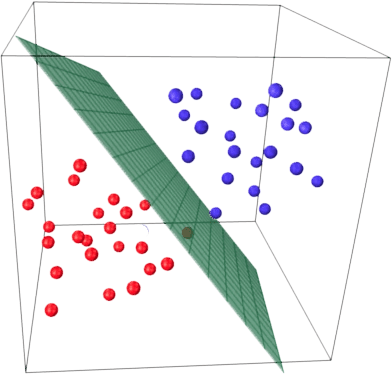

Разделяющая плоскость между двумя классами в пространстве трёх признаков.

Каждая точка изображает один объект. Три его признака задают положение точки в пространстве, цвет обозначает известный класс. Зелёная плоскость — множество объектов с нулевой оценкой. Если двигать точку параллельно плоскости, скалярное произведение с нормалью останется постоянным. При движении вдоль нормали оценка растёт, а при пересечении плоскости меняет знак. На плоском изображении точки могут зрительно накладываться на плоскость. Их класс определяется тем, с какой стороны они находятся в трёхмерном пространстве.

Тот же расчёт проще проверить на двух признаках. В этом случае граница становится прямой, и основание перпендикуляра к ней можно найти вручную.

#### Пример разделения плоскости

Для $w=(1,2)$ уравнение границы имеет вид $x_1+2x_2=0$. У точки $x=(2,1)$ оценка равна $4$, прогноз равен $+1$, а знаковое расстояние равно $4/\sqrt5$. Проекция
$$x_H=(2,1)-\frac45(1,2)=\left(\frac65,-\frac35\right)$$
лежит на границе, поскольку $6/5+2(-3/5)=0$. Для симметричной точки $(-2,-1)$ оценка равна $-4$, и модель выдаёт $-1$.

[figure not shown]

Рисунок 1. Нормаль w направлена в полуплоскость класса +1. Пунктир показывает перпендикуляр от x к его проекции.

### Суррогатные функции потерь

Для одного объекта обозначим $M=g(w,x)y$. Пороговая потеря $L(M)=[M<0]$ считает ошибки при строго отрицательном отступе. В функционалах $Q(w)$ и $\bar Q(w)$ выше используется $[M\le0]$, поэтому там учитываются и объекты на границе. Эти соглашения дают один и тот же результат при $M\ne0$. На графике ниже пороговая функция показана в варианте $[M<0]$.

Пороговая потеря постоянна на каждом интервале $M<0$ и $M>0$ и имеет скачок при $M=0$. Её производная по $M$ равна нулю вдали от границы и не определена в нуле. Если изменить параметры и уменьшить величину отрицательного отступа, потери уменьшатся лишь после смены знака. Суррогаты реагируют на изменение отступа и дают больше информации для оптимизации.

**Кусочно-линейная потеря** (hinge loss) и **логистическая потеря** (logistic loss) имеют вид
$$L_{\mathrm{hinge}}(M)=\max(0,1-M),
\qquad
L_{\mathrm{log}}(M)=\ln(1+e^{-M}).$$
Первая выпукла как максимум двух аффинных функций. В точке $M=1$ у неё излом, где можно использовать субградиент. При $M<0$ она больше единицы, при $M=0$ равна единице, а при $M>0$ неотрицательна. Таким образом, она оценивает сверху как $[M<0]$, так и $[M\le0]$.

Для логистической потери
$$L_{\mathrm{log}}'(M)=-\frac1{1+e^M},
\qquad
L_{\mathrm{log}}''(M)=\frac{e^M}{(1+e^M)^2}>0.$$
Она гладкая, строго выпуклая по $M$ и подходит для градиентных методов. При $M=0$ её значение равно $\ln 2$. Если для сравнения с индикатором нужна верхняя оценка, то $L_{\mathrm{log}}(M)/\ln 2\ge[M\le0]$. Масштабирование на положительную константу сохраняет минимизаторы функционала, составленного из одной этой потери.

При линейной модели $M_i(w)=y_i\langle w,x_i\rangle$ является линейной функцией $w$. Поэтому подстановка $M_i(w)$ в выпуклую потерю и усреднение дают выпуклый функционал по $w$. Если минимум достигается, любой локальный минимум такого функционала является глобальным.

#### Сравнение пяти функций

Обозначение $(u)_+$ означает $\max(0,u)$.

| Потеря | Формула | Поведение |
| --- | --- | --- |
| Логистическая | $\ln(1+e^{-M})$ | Плавно убывает, стремится к нулю при $M\to+\infty$. |
| Кусочно-линейная, hinge | $(1-M)_+=\max(0,1-M)$ | Штрафует и правильный ответ при $0<M<1$. Используется в методе опорных векторов. |
| Кусочно-линейная, персептронная | $(-M)_+=\max(0,-M)$ | Равна нулю при $M\ge0$. Связана с правилом обучения персептрона Розенблатта. |
| Экспоненциальная | $e^{-M}$ | Быстро растёт при больших по модулю отрицательных отступах. |
| Сигмоидная | $2/(1+e^M)$ | Ограничена числами $0$ и $2$. Выпуклость меняется при переходе через $M=0$. |

При $M=-1$ hinge loss равна $2$, персептронная потеря равна $1$, а экспоненциальная равна $e$. При $M=1$ обе кусочно-линейные потери равны нулю, а логистическая остаётся положительной и равна $\ln(1+e^{-1})$. Функции по-разному штрафуют один и тот же отступ, поэтому их минимизация может приводить к разным границам классов.

[figure not shown]

Рисунок 2. Функции потерь по отступу M. Вертикальная шкала ограничена значением 4.

#### Как сравнивать кривые при разных нормировках

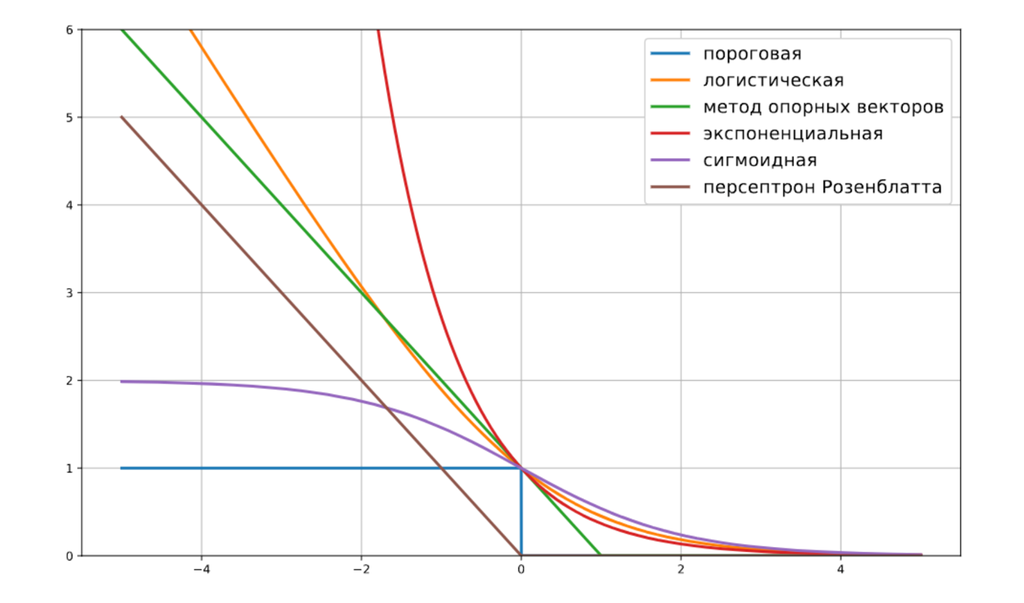

Пороговая и пять суррогатных функций. Логистическая кривая приведена к значению 1 при нулевом отступе.

Чтобы прочитать график, зафиксируйте отступ на горизонтальной оси и сравните высоты кривых. При $M=0$ зелёная, красная, фиолетовая и оранжевая кривые проходят через $1$. Оранжевой кривой соответствует логистическая потеря в масштабе $\log_2(1+e^{-M})=\ln(1+e^{-M})/\ln 2$. На предыдущем рисунке она построена с натуральным логарифмом и даёт $\ln 2\approx0{,}693$ в той же точке. Это объясняет различие высот. При $M=1$ зелёная кривая достигает нуля, тогда как логистическая продолжает плавно убывать. Значение пороговой потери в самой точке разрыва задаётся выбранным соглашением.

### Вероятностный подход

Вместо одной метки модель может выдавать распределение вероятностей по классам. Например, классификатор тональности преобразует текст в вектор признаков $x$ и оценивает вероятности положительной и отрицательной тональности. Ответы с вероятностями $0{,}51$ и $0{,}95$ для положительного класса ведут к одной метке при пороге $0{,}5$, хотя модель оценивает уверенность по-разному. Общую схему классификации текста через признаки и вероятности классов см. в [Lena Voita, NLP Course: Text Classification](https://lena-voita.github.io/nlp_course/text_classification.html).

#### Три класса и два способа их различить

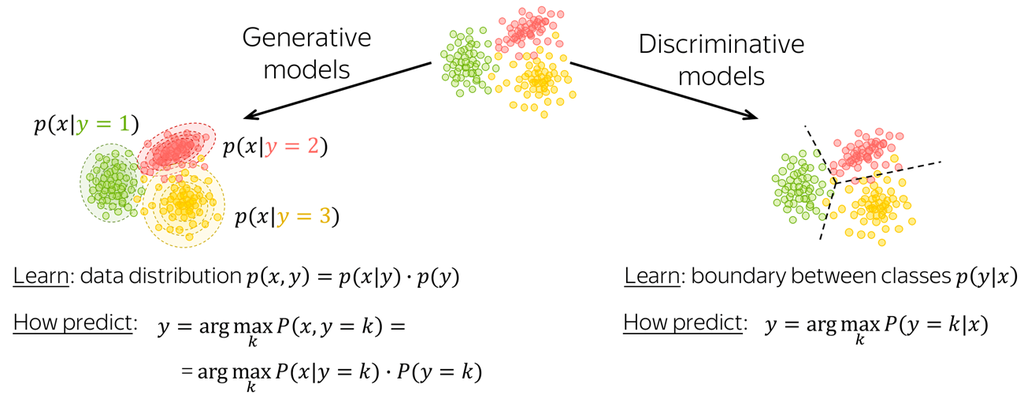

Генеративная модель описывает облака признаков трёх классов, дискриминативная проводит между ними границы. Иллюстрация Лены Войты.

Наверху показана одна и та же выборка. Слева цветные контуры описывают области, характерные для каждого класса. Для новой точки $x$ генеративная модель оценивает, насколько типично её положение для каждого облака, и учитывает частоту соответствующего класса. Справа пунктир делит пространство на области решений. Дискриминативная модель учится выбирать класс точки по её положению. Возле границы небольшое смещение может изменить ответ. При наличии вероятностных оценок граница между двумя конкурирующими классами проходит там, где их вероятности равны и максимальны.

Числа $1,2,3$ на схеме обозначают три метки. Индекс под $\arg\max$ перебирает возможные метки. В формулах ниже им соответствуют $C_1,C_2,C_3$.

### Генеративные и дискриминативные модели

**Генеративная модель** описывает совместное распределение $p(x,y)$ через
$$p(x,y)=p(x\mid y)p(y).$$
Сначала задаётся распределение меток $p(y)$, затем для каждого класса — распределение признаков $p(x\mid y)$. Если задача состоит в выборе наиболее вероятного класса при фиксированном $x$ и равной цене ошибок, правило предсказания имеет вид
$$\hat y=\operatorname*{arg\,max}_{C_i\in Y}
p(x\mid y=C_i)p(y=C_i).$$
Общий для всех классов знаменатель $p(x)$ не меняет порядок сравниваемых значений.

**Дискриминативная модель** описывает условное распределение $p(y\mid x)$ или непосредственно правило разделения классов. Вероятностная модель выбирает класс по правилу
$$\hat y=\operatorname*{arg\,max}_{C_i\in Y}p(y=C_i\mid x).$$
Например, логистическая регрессия параметризует $p(y\mid x)$ напрямую. Линейный классификатор со знаком $g(w,x)$ задаёт границу между классами.

### Определения

Пусть $C_i$ — метка класса из множества $Y=\{C_1,\ldots,C_k\}$.

| Обозначение | Смысл |
| --- | --- |
| $p(y=C_i\mid x)$ | **Апостериорная вероятность** (posterior). Вероятность класса $C_i$ после наблюдения $x$. |
| $p(x\mid y=C_i)$ | **Условное распределение признаков** класса $C_i$. При фиксированном $x$ его значение характеризует правдоподобие наблюдения в этом классе. |
| $p(y=C_i)$ | **Априорная вероятность** класса $C_i$, до наблюдения $x$. |
| $p(x)$ | **Маргинальное распределение** признаков. В формуле Байеса играет роль нормирующего множителя. |

Для дискретных признаков $p(x\mid y=C_i)$ и $p(x)$ являются вероятностями конкретных значений. Для непрерывных признаков это значения плотностей. По формуле полной вероятности или полной плотности
$$p(x)=\sum_{i=1}^{k}p(x\mid y=C_i)p(y=C_i).$$

### Теорема Байеса

Из двух разложений совместного распределения получаем
$$p(x,y=C_i)=p(x\mid y=C_i)p(y=C_i)=p(y=C_i\mid x)p(x).$$
При $p(x)>0$ отсюда следует
$$p(y=C_i\mid x)
=\frac{p(x\mid y=C_i)p(y=C_i)}{p(x)}
=\frac{p(x\mid y=C_i)p(y=C_i)}
{\displaystyle\sum_{j=1}^k p(x\mid y=C_j)p(y=C_j)}.$$
В числителе стоит вклад класса $C_i$, а в знаменателе — сумма вкладов всех классов. Поэтому сумма апостериорных вероятностей равна единице.

**Пример.** Пусть априорные вероятности двух классов равны $0{,}8$ и $0{,}2$, а вероятности наблюдать конкретный дискретный признак $x$ в этих классах равны $0{,}1$ и $0{,}6$. Вклады классов равны $0{,}8\cdot0{,}1=0{,}08$ и $0{,}2\cdot0{,}6=0{,}12$. Тогда $p(x)=0{,}20$, $p(y=C_1\mid x)=0{,}4$ и $p(y=C_2\mid x)=0{,}6$. Выбирается класс $C_2$, поскольку наблюдаемый признак встречается в нём достаточно часто, чтобы перевесить меньшую априорную вероятность.

## 2. Логистическая регрессия

Вернёмся к полезному письму со ссылкой. Линейная оценка $2\cdot1-1=1$ даёт одну метку «спам». Насколько модель уверена в этом ответе? Чтобы придать оценке вероятностный смысл, свяжем её с шансами двух исходов. Сначала выведем вероятность из шансов, затем подберём веса, при которых наблюдаемые ответы получают высокую вероятность.

### Формула Байеса для класса $C_2=1$

Перекодируем бинарные метки. В этом разделе $Y=\{0,1\}$, $C_1=0$ и $C_2=1$. Метка $0$ соответствует прежней метке $-1$, а метка $1$ — прежней $+1$.

Для класса $C_2$ применяем теорему Байеса и раскрываем знаменатель как сумму по двум классам
$$\begin{aligned}
p(y=C_2\mid x)
&=\frac{p(x\mid y=C_2)p(y=C_2)}{p(x)}\\
&=\frac{p(x\mid y=C_2)p(y=C_2)}
{p(x\mid y=C_1)p(y=C_1)+p(x\mid y=C_2)p(y=C_2)}\\
&=\frac{1}{1+\dfrac{p(x\mid y=C_1)p(y=C_1)}{p(x\mid y=C_2)p(y=C_2)}}.
\end{aligned}$$
В последнем переходе числитель и знаменатель поделили на положительный вклад класса $C_2$. Если этот вклад нулевой при $p(x)>0$, вероятность класса $C_2$ равна нулю по первой строке.

### Шансы и логарифм шансов

**Шансы** (odds) класса $C_2$ при наблюдении $x$ — отношение апостериорных вероятностей двух классов. Если вероятность $C_1$ положительна, то
$$\frac{p(y=C_2\mid x)}{p(y=C_1\mid x)}
=
\frac{p(x\mid y=C_2)p(y=C_2)}{p(x\mid y=C_1)p(y=C_1)}.$$
В правой части сократился общий знаменатель $p(x)$. Если вероятность класса $C_2$ равна $0{,}8$, шансы равны $0{,}8/0{,}2=4$. Равным вероятностям соответствуют шансы $1$ и логарифм шансов $0$.

**Логистическая регрессия** задаёт линейную модель логарифма шансов
$$\ln\frac{p(y=C_2\mid x,w)}{p(y=C_1\mid x,w)}=\langle w,x\rangle.$$
Это предположение о связи ответов с признаками. Формула Байеса сама по себе линейности не требует. Если $x_j$ увеличивается на единицу при фиксированных остальных признаках, логарифм шансов меняется на $w_j$, а шансы умножаются на $e^{w_j}$.

### От логарифма шансов к вероятности

Возводим $e$ в степень, равную обеим частям равенства
$$\frac{p(y=C_2\mid x,w)}{p(y=C_1\mid x,w)}=e^{\langle w,x\rangle}.$$
Так как $p(y=C_1\mid x,w)+p(y=C_2\mid x,w)=1$, обозначим вероятность второго класса через $p$. Тогда
$$\frac{p}{1-p}=e^{\langle w,x\rangle},
\qquad
p(1+e^{\langle w,x\rangle})=e^{\langle w,x\rangle}.$$
Делим на $1+e^{\langle w,x\rangle}$ и упрощаем
$$p(y=C_2\mid x,w)
=\frac{e^{\langle w,x\rangle}}{1+e^{\langle w,x\rangle}}
=\frac1{1+e^{-\langle w,x\rangle}}.$$

### Сигмоида

**Сигмоида** задаётся формулой
$$\sigma(z)=\frac1{1+e^{-z}},
\qquad
p(y=C_2\mid x,w)=\sigma(\langle w,x\rangle).$$
При $z=0$ она равна $1/2$. Сигмоида возрастает от $0$ до $1$ и при конечном $z$ принимает значения строго внутри $(0,1)$. Симметрия графика относительно точки $(0,1/2)$ следует из равенства
$$\sigma(-z)=\frac1{1+e^z}
=\frac{e^{-z}}{1+e^{-z}}
=1-\sigma(z).$$
Дифференцирование даёт формулу для производной
$$\sigma'(z)=\frac{e^{-z}}{(1+e^{-z})^2}
=\frac1{1+e^{-z}}\cdot\frac{e^{-z}}{1+e^{-z}}
=\sigma(z)(1-\sigma(z)).$$
Производная положительна. Она максимальна при $z=0$, где равна $1/4$, и стремится к нулю на обоих концах графика.

[figure not shown]

Рисунок 3. Сигмоида переводит логарифм шансов z в вероятность. Выделенная точка соответствует равновероятным классам.

### Модель вероятностей и правило классификации

Вероятности двух меток для объекта $x$ равны
$$p(y=C_2\mid x,w)=\sigma(\langle w,x\rangle),
\qquad
p(y=C_1\mid x,w)=1-\sigma(\langle w,x\rangle).$$
Например, при $\langle w,x\rangle=\ln 3$ шансы класса $C_2$ равны $3$, а его вероятность равна $3/(1+3)=0{,}75$. При $\langle w,x\rangle=-\ln3$ его вероятность равна $0{,}25$.

При пороге $1/2$ и правиле выбора $C_2$ в случае равенства прогнозируем $C_2$ тогда и только тогда, когда $\langle w,x\rangle\ge0$. Именно поэтому логистическая регрессия строит линейную границу, хотя зависимость вероятности от оценки нелинейна. Для произвольного порога $\tau\in(0,1)$ критерием выбора $C_2$ служит условие
$$\sigma(\langle w,x\rangle)\ge\tau
\quad\Longleftrightarrow\quad
\langle w,x\rangle\ge\ln\frac{\tau}{1-\tau}.$$
Порог $1/2$ соответствует выбору более вероятного класса. Другой порог может понадобиться, если цена двух видов ошибок различается.

Для письма с оценкой $1$ получаем $\sigma(1)=1/(1+e^{-1})\approx0{,}731$. При пороге $0{,}5$ письмо попадёт в спам, при пороге $0{,}8$ останется в обычной почте. Его оценка и вероятность в этих двух расчётах одинаковы. Меняется действие системы после получения прогноза.

### Метод максимального правдоподобия

Зафиксируем признаки $x_1,\ldots,x_\ell$. Если ответы $y_i$ условно независимы при заданных признаках и $w$, **правдоподобие** наблюдаемых меток имеет вид
$$\mathcal L(w)=\prod_{i=1}^{\ell}p(y_i\mid x_i,w).$$
Здесь фиксируются и объекты, и фактические ответы, а $w$ меняется. Для любого конечного $w$ вероятности меток в логистической модели положительны. Логарифм превращает произведение в сумму и сохраняет порядок значений правдоподобия
$$\ln\mathcal L(w)=\sum_{i=1}^{\ell}\ln p(y_i\mid x_i,w),
\qquad
w^*\in\operatorname*{arg\,max}_{w\in\mathbb R^n}
\sum_{i=1}^{\ell}\ln p(y_i\mid x_i,w),$$
если конечный максимум существует. **Метод максимального правдоподобия** (maximum likelihood estimation, MLE) выбирает такой вектор $w^*$.

**Зачем нужно произведение.** Пусть истинные ответы для двух объектов равны $1$ и $0$. При одном наборе весов вероятности класса $1$ равны $0{,}8$ и $0{,}3$. Тогда модель приписала наблюдаемым ответам вероятности $0{,}8$ и $1-0{,}3=0{,}7$. Правдоподобие равно $0{,}8\cdot0{,}7=0{,}56$. Если при других весах прогнозы равны $0{,}6$ и $0{,}6$, получаем $0{,}6\cdot(1-0{,}6)=0{,}24$. Из этих двух наборов весов метод предпочтёт первый. В каждом множителе используется вероятность именно того ответа, который действительно наблюдался.

### Нахождение параметров

Обозначим $\hat p_i=\sigma(\langle w,x_i\rangle)$. Тогда условное распределение ответа $y_i\in\{0,1\}$ — распределение Бернулли с параметром $\hat p_i$
$$p(y_i\mid x_i,w)=\hat p_i^{\,y_i}(1-\hat p_i)^{1-y_i}.$$
При $y_i=1$ остаётся множитель $\hat p_i$, а при $y_i=0$ — $1-\hat p_i$. Поэтому
$$\ln\mathcal L(w)=
\sum_{i=1}^{\ell}\left(y_i\ln\hat p_i+(1-y_i)\ln(1-\hat p_i)\right).$$
Максимизация логарифма правдоподобия эквивалентна минимизации среднего отрицательного логарифма правдоподобия, то есть **бинарной кросс-энтропии**
$$Q_{\mathrm{log}}(w)
=-\frac1\ell\sum_{i=1}^{\ell}
\left(y_i\ln\hat p_i+(1-y_i)\ln(1-\hat p_i)\right).$$
Каждое слагаемое до усреднения равно $-\ln$ вероятности истинного класса. При прогнозе $\hat p_i=0{,}8$ вклад равен $-\ln0{,}8\approx0{,}223$ для $y_i=1$ и $-\ln0{,}2\approx1{,}609$ для $y_i=0$.

#### Связь с потерей через отступ

Положим $z_i=\langle w,x_i\rangle$ и вернёмся к меткам $y_i^\pm=2y_i-1\in\{-1,+1\}$. При $y_i=1$ вероятность истинного класса равна $\sigma(z_i)$. При $y_i=0$ она равна $1-\sigma(z_i)=\sigma(-z_i)$. Поэтому обе формулы можно записать через отступ $M_i(w)=y_i^\pm z_i$
$$p(y_i\mid x_i,w)=\sigma(M_i(w)),
\qquad
-\ln p(y_i\mid x_i,w)
=-\ln\sigma(M_i(w))
=\ln(1+e^{-M_i(w)}).$$
Так логистическая потеря из первого раздела получается из вероятностной модели второго раздела.

#### Градиент логарифма правдоподобия

Поскольку $z_i=\langle w,x_i\rangle$, имеем $\nabla_w z_i=x_i$. По правилу цепочки
$$\nabla_w\hat p_i
=\sigma'(z_i)x_i
=\hat p_i(1-\hat p_i)x_i.$$
Продифференцируем слагаемое $\ln p(y_i\mid x_i,w)$
$$\begin{aligned}
\nabla_w\left(y_i\ln\hat p_i+(1-y_i)\ln(1-\hat p_i)\right)
&=\left(\frac{y_i}{\hat p_i}-\frac{1-y_i}{1-\hat p_i}\right)\nabla_w\hat p_i\\
&=\bigl(y_i(1-\hat p_i)-(1-y_i)\hat p_i\bigr)x_i\\
&=(y_i-\hat p_i)x_i.
\end{aligned}$$
После суммирования получаем
$$\nabla_w\ln\mathcal L(w)=\sum_{i=1}^{\ell}(y_i-\hat p_i)x_i,
\qquad
\nabla_w Q_{\mathrm{log}}(w)=\frac1\ell\sum_{i=1}^{\ell}(\hat p_i-y_i)x_i.$$
Для $y_i=1$ коэффициент $y_i-\hat p_i$ положителен, а для $y_i=0$ отрицателен. В градиентном подъёме вклад первого объекта толкает $w$ в направлении $x_i$, повышая его оценку $z_i$. Вклад второго направлен в противоположную сторону. Полный шаг складывает вклады всех объектов.

#### Пример. Один шаг обучения на письме

Для полезного письма $x=(1,1)$ метка в кодировке $\{0,1\}$ равна $y=0$. При $w=(2,-1)$ модель дала спаму вероятность $\hat p\approx0{,}731$. Градиент отрицательного логарифма правдоподобия **одного объекта** равен $(\hat p-y)x\approx(0{,}731,0{,}731)$. Сделаем шаг спуска длины $\eta=0{,}1$
$$w_{\text{нов}}=(2,-1)-0{,}1(0{,}731,0{,}731)
\approx(1{,}927,-1{,}073).$$
Теперь оценка того же письма равна примерно $0{,}854$, а вероятность спама снизилась до $\sigma(0{,}854)\approx0{,}701$. Письмо пока ещё ошибочно помечается как спам при пороге $0{,}5$. Однако вероятность истинного класса выросла с $0{,}269$ до $0{,}299$. Логистическая потеря уже отразила улучшение, хотя пороговая по-прежнему равна единице. При шаге по всей выборке градиент усредняет вклады всех писем.

#### Выпуклость, градиентный шаг и разделимость

Для минимизации $Q_{\mathrm{log}}$ градиентный шаг с длиной $\eta_t>0$ записывается так
$$w^{(t+1)}=w^{(t)}-
\frac{\eta_t}{\ell}\sum_{i=1}^{\ell}
\bigl(\sigma(\langle w^{(t)},x_i\rangle)-y_i\bigr)x_i.$$
Проверим выпуклость через гессиан
$$\nabla_w^2 Q_{\mathrm{log}}(w)=
\frac1\ell\sum_{i=1}^{\ell}\hat p_i(1-\hat p_i)x_i x_i^{\mathsf T}.$$
Для любого $v\in\mathbb R^n$ квадратичная форма этого гессиана равна
$$v^{\mathsf T}\nabla_w^2 Q_{\mathrm{log}}(w)v
=\frac1\ell\sum_{i=1}^{\ell}\hat p_i(1-\hat p_i)\langle v,x_i\rangle^2
\ge0.$$
Следовательно, $Q_{\mathrm{log}}$ выпукла, а $\ln\mathcal L(w)$ вогнут. Если векторы $x_i$ порождают $\mathbb R^n$, форма положительна при $v\ne0$ для любого конечного $w$. В этом случае конечный минимум, если он достигается, единственный.

Если выборка строго линейно разделима, существует $w$ со всеми $M_i(w)>0$. Для $cw$ при $c\to+\infty$ отступы растут, и $Q_{\mathrm{log}}(cw)$ стремится к нулю. При любом конечном векторе весов все слагаемые потерь положительны, поэтому нуль недостижим. Если нужна конечная оценка, можно добавить штраф $\lambda\|w\|_2^2$ с $\lambda>0$ для всех компонент $w$. Это даёт строго выпуклый функционал, который растёт при $\|w\|_2\to\infty$ и достигает единственного минимума.

При больших по модулю отступах значение потери можно вычислять через равносильную формулу
$$\ln(1+e^{-M})=\max(0,-M)+\ln(1+e^{-|M|}).$$
Её получают, выделяя $e^{-M}$ из скобок при $M<0$. Экспонента в правой части вычисляется только с неположительным показателем, что устраняет переполнение на этом шаге.

## 3. Многоклассовая классификация

### Обзор многоклассовой классификации

В многоклассовой задаче каждому объекту назначается одна из $k>2$ меток. Обучающая выборка имеет вид
$$X^\ell=\{(x_i,y_i)\}_{i=1}^{\ell},
\qquad x_i\in\mathbb R^n,\qquad y_i\in Y,\qquad
Y=\{C_1,\ldots,C_k\}.$$
Один способ получить многоклассовый алгоритм — свести задачу к нескольким бинарным. **One-vs-Rest** (OvR) обучает $k$ классификаторов, по одному для каждого класса. **One-vs-One** (OvO) обучает классификатор для каждой неупорядоченной пары классов, всего $k(k-1)/2$. **Многоклассовая логистическая регрессия** обучает совместную вероятностную модель на основе softmax.

Представим, что письмо требуется направить в один из трёх отделов — поддержка, продажи или бухгалтерия. В обучающих данных для каждого письма указан ровно один отдел. OvR задаёт для каждого отдела вопрос «сюда или в другой отдел?». OvO устраивает три попарных сравнения. Softmax сразу распределяет единичную сумму вероятностей между всеми тремя отделами. Во всех случаях конечный ответ один, но промежуточные оценки имеют разный смысл.

### One-vs-Rest (OvR)

Для каждого фиксированного класса $C_i$ создаём бинарную задачу на всей выборке. Объекты класса $C_i$ имеют метку $+1$, все остальные — метку $-1$. Обозначим через $a_i(x)$ вещественную оценку принадлежности объекта $x$ к $C_i$, например результат линейной дискриминантной функции или вероятность в соответствующей бинарной модели. Затем выбираем класс по правилу
$$\hat y=\operatorname*{arg\,max}_{C_i\in Y} a_i(x).$$
Если оценки $(a_1(x),a_2(x),a_3(x))=(-0{,}6,1{,}4,0{,}8)$, побеждает $C_2$. Если все оценки отрицательны, $\operatorname*{arg\,max}$ всё равно выбирает класс с наибольшей оценкой. Если максимум достигается у нескольких классов, применяется заранее заданное правило разрешения ничьей.

Использование одних лишь меток $-1$ и $+1$ теряет информацию о величине оценки. В примере знаки одновременно выделяют $C_2$ и $C_3$. Вещественные оценки помогают разрешить такое перекрытие, если их шкалы сопоставимы. Бинарные модели обучаются отдельно, поэтому их вероятности могут не суммироваться в единицу. Например, тройка $(0{,}2,0{,}8,0{,}6)$ даёт однозначный максимум, но сумма равна $1{,}6$.

OvR требует всего $k$ независимых обучений. При редком классе его положительных объектов намного меньше, чем отрицательных. Даже при одинаковом размере всех $k$ классов доля положительных объектов для каждого классификатора равна $1/k$. Поэтому при большом $k$ дисбаланс возникает уже при самом сведении задачи к бинарным.

### Многоклассовая логистическая регрессия

Каждому классу $C_i$ соответствует вектор $w_i\in\mathbb R^n$. Все векторы можно собрать в матрицу $W$ размера $k\times n$, поместив $w_i^{\mathsf T}$ в строку $i$. Правило выбора класса имеет вид
$$a(x)=\operatorname*{arg\,max}_{C_i\in Y}\langle w_i,x\rangle.$$
Обозначим $z_i=\langle w_i,x\rangle$. **Softmax** преобразует вектор оценок $(z_1,\ldots,z_k)$ в распределение вероятностей
$$p(y=C_i\mid x,W)
=\frac{\exp\langle w_i,x\rangle}
{\displaystyle\sum_{j=1}^k\exp\langle w_j,x\rangle}
=\operatorname{softmax}(z_1,\ldots,z_k)_i.$$
Каждый числитель положителен, а знаменатель является суммой всех числителей. Поэтому сумма вероятностей равна $1$. Экспонента строго возрастает, а знаменатель один для всех классов. Следовательно, наибольшая исходная оценка соответствует наибольшей вероятности. При совпадении двух оценок возможная граница между классами $C_i$ и $C_j$ лежит на множестве $\langle w_i-w_j,x\rangle=0$. Участок этого множества становится границей предсказаний только там, где эти классы имеют максимальную оценку среди всех классов.

#### Пример вычисления softmax

Для трёх классов с оценками $(0,\ln 2,\ln 3)$ экспоненты равны $(1,2,3)$. Их сумма равна $6$, поэтому
$$\operatorname{softmax}(0,\ln 2,\ln 3)=
\left(\frac16,\frac26,\frac36\right).$$
Наибольшая вероятность равна $1/2$, и модель выбирает $C_3$.

Если эти три метки соответствуют отделам из примера, письмо отправится в бухгалтерию. Для победы достаточно опередить каждый другой отдел по отдельности. Это объясняет, почему в многоклассовой задаче правило максимума работает и при вероятности победителя меньше половины.

При прибавлении одного числа ко всем оценкам оно сокращается в дроби
$$\frac{e^{z_i+c}}{\sum_{j=1}^k e^{z_j+c}}
=\frac{e^{c}e^{z_i}}{e^{c}\sum_{j=1}^k e^{z_j}}
=\frac{e^{z_i}}{\sum_{j=1}^k e^{z_j}}.$$
Для вычислений выбирают сдвиг $c=-\max_j z_j$. После него все показатели неположительны, а одна из экспонент равна $1$.

#### Обучение по правдоподобию

При условной независимости меток логарифм правдоподобия равен
$$\ln\mathcal L(W)=\sum_{i=1}^{\ell}\ln p(y_i\mid x_i,W)
\longrightarrow\max_W.$$
Здесь индекс $i$ нумерует объекты. Пусть $r_i$ — номер истинного класса объекта, то есть $y_i=C_{r_i}$. Для каждой обучающей пары логарифм вероятности раскрывается так
$$\ln p(y_i\mid x_i,W)
=\langle w_{r_i},x_i\rangle
-\ln\!\left(\sum_{j=1}^k\exp\langle w_j,x_i\rangle\right).$$
Изменение знака и деление на $\ell$ превращают максимизацию в минимизацию **многоклассовой кросс-энтропии**
$$Q_{\mathrm{softmax}}(W)
=-\frac1\ell\sum_{i=1}^{\ell}\sum_{j=1}^{k}
[y_i=C_j]\ln p(y=C_j\mid x_i,W).$$
Во внутренней сумме остаётся только член для истинной метки. Если для неё модель дала вероятность $1/2$, вклад объекта до усреднения равен $\ln2$. Если дала $1/6$, вклад равен $\ln6$.

#### Градиент и случай двух классов

Для веса $w_j$ производная оценки $\langle w_{r_i},x_i\rangle$ равна $[y_i=C_j]x_i$. Производная логарифма суммы экспонент равна
$$\nabla_{w_j}\ln\!\left(\sum_{h=1}^k\exp\langle w_h,x_i\rangle\right)
=\frac{\exp\langle w_j,x_i\rangle}{\sum_{h=1}^k\exp\langle w_h,x_i\rangle}\,x_i
=p(y=C_j\mid x_i,W)x_i.$$
Вычитая, получаем градиент логарифма правдоподобия по вектору весов класса $C_j$
$$\nabla_{w_j}\ln\mathcal L(W)
=\sum_{i=1}^{\ell}\bigl([y_i=C_j]-p(y=C_j\mid x_i,W)\bigr)x_i.$$
Градиент кросс-энтропии по $w_j$ равен этому выражению со знаком минус и множителем $1/\ell$. Как и в бинарном случае, в каждом слагаемом сравниваются фактическая принадлежность к классу и вероятность, которую ему дала модель.

При $k=2$ вероятность второго класса упрощается
$$\begin{aligned}
p(y=C_2\mid x,W)
&=\frac{e^{\langle w_2,x\rangle}}
{e^{\langle w_1,x\rangle}+e^{\langle w_2,x\rangle}}\\
&=\frac1{1+e^{-\langle w_2-w_1,x\rangle}}
=\sigma(\langle w_2-w_1,x\rangle).
\end{aligned}$$
Это бинарная логистическая регрессия с $w=w_2-w_1$. В общем случае прибавление одного и того же вектора ко всем $w_i$ также сохраняет вероятности, поскольку добавляет общую величину к оценкам каждого объекта. Можно, например, зафиксировать $w_1=0$, вычитая исходный $w_1$ из каждого вектора.

### One-vs-One (OvO)

Для каждой пары $(C_i,C_j)$, где $i<j$, берём только объекты этих классов и обучаем классификатор различать их. Первый класс можно выбрать $k$ способами, второй — $k-1$ способами. Деление на два убирает двойной подсчёт пары. Всего получаем
$$\binom{k}{2}=\frac{k(k-1)}{2}$$
классификаторов.

При предсказании каждый из них отдаёт один голос одному из двух классов. Побеждает класс с наибольшим числом голосов. Для трёх классов возможны, например, такие исходы.

| Сравнение | Первый вариант | Второй вариант |
| --- | --- | --- |
| $C_1$ против $C_2$ | $C_1$ | $C_1$ |
| $C_1$ против $C_3$ | $C_3$ | $C_3$ |
| $C_2$ против $C_3$ | $C_3$ | $C_2$ |
| Число голосов за $C_1,C_2,C_3$ | $(1,0,2)$ | $(1,1,1)$ |

В первом варианте выбирается $C_3$. Во втором образуется цикл предпочтений. Для таких случаев требуется правило разрешения ничьей, например выбор по фиксированному порядку классов.

Каждый классификатор решает локальную задачу на двух классах. Если объектов класса $C_i$ в обучающей выборке $\ell_i$, объём данных для пары $C_i,C_j$ равен $\ell_i+\ell_j$. Отдельные обучения могут быть небольшими, но число моделей растёт квадратично по $k$. При обычном голосовании на новом объекте требуется применить все эти модели.

### Сравнение и выбор

| Метод | Число моделей | Данные для обучения | Когда подходит |
| --- | --- | --- | --- |
| OvR | $k$ | Каждый классификатор использует всю выборку с бинарными метками. | При большом $k$ или ограниченных ресурсах, если оценки бинарных моделей сопоставимы. Следует учитывать дисбаланс отдельных задач. |
| OvO | $k(k-1)/2$ | Каждый классификатор использует только объекты своей пары классов. | При небольшом или среднем $k$ и хорошей попарной разделимости. Нужно учитывать стоимость голосования и возможность ничьей. |
| Softmax | Одна совместная модель с $k$ векторами весов | Вероятности всех классов вычисляются и оцениваются совместно на всей выборке. | Когда требуется единое распределение вероятностей по классам и подходит линейная модель для оценок. |

Для $k=4$ OvR обучает $4$ бинарных классификатора, а OvO — $6$. Softmax обучает одну модель с четырьмя векторами весов. В OvR для каждого класса есть своя оценка, в OvO решение определяется попарными голосами, а softmax сравнивает вероятности, нормированные по всем классам. Фактическое время обучения OvR и OvO зависит также от размера отдельных выборок и алгоритма оптимизации.